# elt2_target_analysis

Robert Williams

3/9/2022

load packages

```r
library(tidyverse)
```

load data files

```r
elt2_regulated_genes <- read_csv(file = "../../05_elt2_RNAseq/03_output/elt2_regulated_gene_sets.csv")

embryo_chip <- read.table(file = "../../../David/01_promoters/03_output/LE.promoters.hilo.tsv") %>% rownames_to_column(var = "WBGeneID")
L1_chip <- read.table(file = "../../../David/01_promoters/03_output/L1.promoters.hilo.tsv") %>% rownames_to_column(var = "WBGeneID")
L3_chip <- read.table(file = "../../../David/01_promoters/03_output/L3.promoters.hilo.tsv") %>% rownames_to_column(var = "WBGeneID")

embryo_intestine_gene_categories <- read_csv(file = "../../03_emb_L1_L3_intestine_RNAseq/03_output/intestine_gene_categories/embryo_intestine_gene_categories.csv")
L1_intestine_gene_categories <- read_csv(file = "../../03_emb_L1_L3_intestine_RNAseq/03_output/intestine_gene_categories/L1_intestine_gene_categories.csv")
L3_intestine_gene_categories <- read_csv(file = "../../03_emb_L1_L3_intestine_RNAseq/03_output/intestine_gene_categories/L3_intestine_gene_categories.csv")
```

Join the data

```r
rna_chip_df <- function(chip_df, category_df){
  chip_df %>% mutate(promoter_status = case_when(!is.na(IDR_mean) ~ "bound",
                                               is.na(IDR_mean) ~ "not_bound")) %>%
  left_join(category_df, by = "WBGeneID") %>%
  left_join(elt2_regulated_genes %>% select(-wormbase_gseq, -wikigene_name), by = "WBGeneID") %>%
  select(WBGeneID, promoter_status, intestine_expression, elt2_ko = description) %>%
  mutate(intestine_expression = case_when(intestine_expression == "enriched" ~ "enriched",
                                          intestine_expression != "enriched" ~ "not_enriched",
                                          TRUE ~ "not_enriched")) %>%
  rows_update(tibble(WBGeneID = "WBGene00001250", promoter_status = "bound"), by = "WBGeneID")
}

embryo_rna_chip <- rna_chip_df(embryo_chip, embryo_intestine_gene_categories)
L1_rna_chip <- rna_chip_df(L1_chip, L1_intestine_gene_categories)
L3_rna_chip <- rna_chip_df(L3_chip, L3_intestine_gene_categories)

all_stages_chip <- data.frame(L1_rna_chip, stage = "L1") %>% bind_rows(data.frame(embryo_rna_chip, stage = "embryo")) %>% bind_rows(data.frame(L3_rna_chip, stage = "L3"))
all_stages_chip$stage <- factor(all_stages_chip$stage, levels = c("embryo", "L1", "L3"))

all_stages_chip <- all_stages_chip %>% mutate(elt2_ko = case_when(elt2_ko == "up_ELT2_minus" ~ "repressed",
                                               elt2_ko == "down_ELT2_minus" ~ "activated",
                                               elt2_ko == "unchanged_ELT2_minus" ~ "independent"),
                           elt2_ko = fct_relevel(elt2_ko, c("activated", "repressed", "independent")))


head(all_stages_chip)
```

```
##         WBGeneID promoter_status intestine_expression     elt2_ko stage
## 1 WBGene00011364           bound             enriched   repressed    L1
## 2 WBGene00016544           bound             enriched independent    L1
## 3 WBGene00008246           bound             enriched        <NA>    L1
## 4 WBGene00001940       not_bound             enriched        <NA>    L1
## 5 WBGene00007404       not_bound             enriched   activated    L1
## 6 WBGene00009854       not_bound             enriched        <NA>    L1
```

# Question: How many intestine enriched genes have ELT-2 binding?

```r
all_stages_chip %>% group_by(stage, promoter_status) %>% summarise(pop = n()) %>% pivot_wider(names_from = promoter_status, values_from = pop) %>% rename(pop_bound_success = bound, pop_bound_fail = not_bound)
```

```
## # A tibble: 3 × 3
## # Groups:   stage [3]
##   stage  pop_bound_success pop_bound_fail
##   <fct>              <int>          <int>
## 1 embryo              2630          17355
## 2 L1                  3241          16744
## 3 L3                  5044          14941
```

```r
bound_expressed_hyper <- all_stages_chip %>% filter(intestine_expression == "enriched") %>%
  group_by(stage, intestine_expression, promoter_status) %>%
  summarise(observed = n()) %>%
  ungroup() %>%
  group_by(stage, intestine_expression) %>%
  mutate(intestine_totals = sum(observed)) %>%
  ungroup() %>%
  group_by(stage, promoter_status) %>%
  mutate(promoter_totals = sum(observed)) %>%
  ungroup() %>%
  left_join(all_stages_chip %>%
              group_by(stage, promoter_status) %>%
              summarise(pop = n()) %>%
              pivot_wider(names_from = promoter_status, values_from = pop) %>%
              rename(pop_bound_success = bound, pop_bound_fail = not_bound),
            by = "stage") %>%
  rowwise() %>%
  mutate(dhyper = dhyper(x = observed, k = intestine_totals , m = pop_bound_success, n = pop_bound_fail),
         expected = intestine_totals*pop_bound_success/(pop_bound_success+pop_bound_fail)) %>%
  pivot_longer(cols = c(observed, expected), names_to = "gene_type", values_to = "genes")%>%
  ungroup() %>%
  mutate(padj = p.adjust(dhyper, method = "BH")) %>%
  mutate(star = case_when(
    gene_type == "observed" & padj > 0.01 ~ "~",
    gene_type == "observed" & padj < 1*10^-10 ~ "***",
    gene_type == "observed" & padj < 1*10^-5 ~ "**",
    gene_type == "observed" & padj < 0.01 ~ "*"
                          ))
bound_expressed_hyper
```

```
## # A tibble: 12 × 12
##    stage  intestine_expression promoter_status intestine_totals promoter_totals
##    <fct>  <chr>                <chr>                      <int>           <int>
##  1 embryo enriched             bound                       1745             572
##  2 embryo enriched             bound                       1745             572
##  3 embryo enriched             not_bound                   1745            1173
##  4 embryo enriched             not_bound                   1745            1173
##  5 L1     enriched             bound                       1485             872
##  6 L1     enriched             bound                       1485             872
##  7 L1     enriched             not_bound                   1485             613
##  8 L1     enriched             not_bound                   1485             613
##  9 L3     enriched             bound                       1445            1130
## 10 L3     enriched             bound                       1445            1130
## 11 L3     enriched             not_bound                   1445             315
## 12 L3     enriched             not_bound                   1445             315
## # … with 7 more variables: pop_bound_success <int>, pop_bound_fail <int>,
## #   dhyper <dbl>, gene_type <chr>, genes <dbl>, padj <dbl>, star <chr>
```

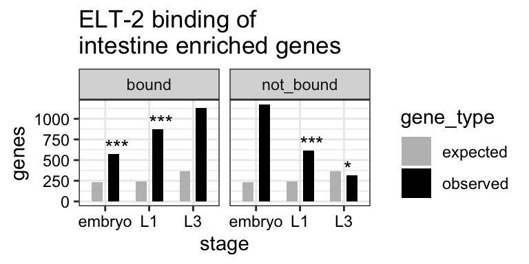

```r
bound_expressed_hyper_plot <- bound_expressed_hyper %>%
  ggplot(aes(x = stage, y = genes, fill = gene_type, label = star)) +
  geom_bar(position = position_dodge(width=0.75), stat = "identity", width = 0.5) +
  geom_text(vjust = 0, hjust = 0) +
  scale_fill_manual(values = c("grey", "black")) +
  # ylim(c(0, max(bound_expressed_hyper$genes)+150)) +
  scale_y_continuous(breaks = seq(0,3000, by = 250)) +
  theme_bw() +
  facet_wrap(~promoter_status) +
  theme(axis.text.x=element_text(colour="black"),
        axis.text.y=element_text(colour="black")) +
  ggtitle("ELT-2 binding of\nintestine enriched genes")
bound_expressed_hyper_plot
```

```r
# ggsave(bound_expressed_hyper_plot, file = "../03_output/Gene_Set_Overlaps/bound_expressed_gene_counts_plot.pdf", width = 3.5, height = 2)
```

Interpretation: More embryo enriched genes are not bound, bound genes increase over developmental time.

# Question: How many ELT-2 targets are differentially expressed

```r
bound_regulated_hyper <- all_stages_chip %>%
  drop_na(elt2_ko) %>%
  filter(promoter_status == "bound") %>%
  group_by(stage, elt2_ko, promoter_status) %>%
  summarise(observed = n()) %>%
  ungroup() %>%
  group_by(stage, elt2_ko) %>%
  mutate(elt2_ko_totals = sum(observed)) %>%
  ungroup() %>%
  group_by(stage, promoter_status) %>%
  mutate(promoter_totals = sum(observed)) %>%
  left_join(all_stages_chip %>%
              drop_na(elt2_ko) %>%
              group_by(stage, elt2_ko) %>%
              summarise(pop_regulated_success = n()) %>%
              mutate(pop_regulated_fail = 11461),
            by = c("stage", "elt2_ko")) %>%
  # mutate(pop_bound_success = 2239, pop_bound_fail = 6285) %>%
  ungroup() %>%
  rowwise() %>%
  mutate(dhyper = dhyper(x = observed, k = elt2_ko_totals , m = pop_regulated_success, n = pop_regulated_fail),
         expected = elt2_ko_totals*pop_regulated_success/(pop_regulated_success+pop_regulated_fail)) %>%
  pivot_longer(cols = c(observed, expected), names_to = "gene_type", values_to = "genes")%>%
  ungroup() %>%
  mutate(padj = p.adjust(dhyper, method = "BH")) %>%
  mutate(star = case_when(
    gene_type == "observed" & padj > 0.01 ~ "~",
    gene_type == "observed" & padj < 1*10^-10 ~ "***",
    gene_type == "observed" & padj < 1*10^-5 ~ "**",
    gene_type == "observed" & padj < 0.01 ~ "*"
                          ))
bound_regulated_hyper
```

```
## # A tibble: 18 × 12
##    stage elt2_ko promoter_status elt2_ko_totals promoter_totals pop_regulated_s…
##    <fct> <fct>   <chr>                    <int>           <int>            <int>
##  1 embr… activa… bound                       92            1900              300
##  2 embr… activa… bound                       92            1900              300
##  3 embr… repres… bound                      121            1900              715
##  4 embr… repres… bound                      121            1900              715
##  5 embr… indepe… bound                     1687            1900             7509
##  6 embr… indepe… bound                     1687            1900             7509
##  7 L1    activa… bound                      173            2240              300
##  8 L1    activa… bound                      173            2240              300
##  9 L1    repres… bound                      210            2240              715
## 10 L1    repres… bound                      210            2240              715
## 11 L1    indepe… bound                     1857            2240             7509
## 12 L1    indepe… bound                     1857            2240             7509
## 13 L3    activa… bound                      220            3542              300
## 14 L3    activa… bound                      220            3542              300
## 15 L3    repres… bound                      279            3542              715
## 16 L3    repres… bound                      279            3542              715
## 17 L3    indepe… bound                     3043            3542             7509
## 18 L3    indepe… bound                     3043            3542             7509
## # … with 6 more variables: pop_regulated_fail <dbl>, dhyper <dbl>,
## #   gene_type <chr>, genes <dbl>, padj <dbl>, star <chr>
```

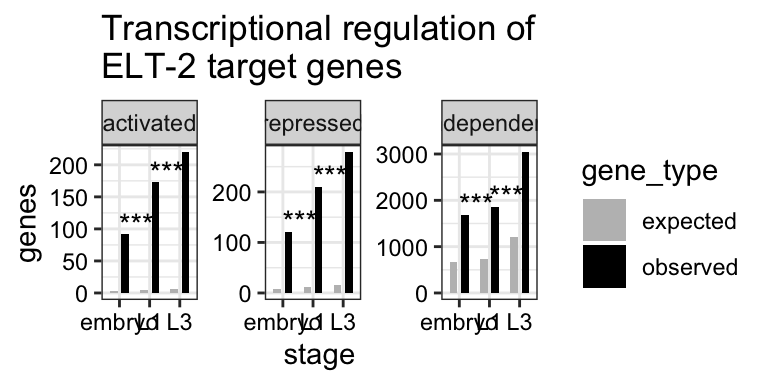

```r
bound_regulated_hyper_plot <- bound_regulated_hyper %>%
  ggplot(aes(x = stage, y = genes, fill = gene_type, label = star)) +
  geom_bar(position = position_dodge(width=0.75), stat = "identity", width = 0.5) +
  geom_text(vjust = 0, hjust = 0) +
  scale_fill_manual(values = c("grey", "black")) +
  # scale_y_continuous(breaks = seq(0, 4000, by = 500)) +
  theme_bw() +
  facet_wrap(elt2_ko~., scales = "free") +
  theme(axis.text.x=element_text(colour="black"),
        axis.text.y=element_text(colour="black")) +
  ggtitle("Transcriptional regulation of\nELT-2 target genes")

bound_regulated_hyper_plot
```

```r
# ggsave(bound_regulated_hyper_plot, file = "../03_output/Gene_Set_Overlaps/bound_only_regulated_gene_counts_plot.pdf", width = 5, height = 2)
```

Interpretation: Most genes do not respond to ELT-2 deletion, either bound or not bound. A subset of bound genes are up, and a subset are down - consider as direct regulated targets. A subset of genes not bound by ELT-2 also respond to ELT-2 deletion - consider as indirect targets. Higher transcript abundance in the absence of ELT-2 suggests repression or negative regulation. The large number negatively regulated bound genes is surprising, as ELT-2 is considered a transcriptional activator.

# Question: Are bound and differentially expressed genes intestine enriched?

```r
bound_intestine_regulated_genes <- all_stages_chip %>%
  filter(promoter_status == "bound", elt2_ko != "independent") %>%
  drop_na(elt2_ko) %>%
  group_by(stage, elt2_ko, intestine_expression) %>%
  summarise(observed = n()) %>%
  ungroup() %>%
  group_by(stage, elt2_ko) %>%
  mutate(elt2_ko_totals = sum(observed)) %>%
  ungroup() %>%
  group_by(stage, intestine_expression) %>%
  mutate(intestine_totals = sum(observed)) %>%
  ungroup() %>%
  # mutate(pop_bound_success = 541, pop_bound_fail = 1698) %>%
  left_join(all_stages_chip %>%
              group_by(stage, promoter_status) %>%
              summarise(pop = n()) %>%
              pivot_wider(names_from = promoter_status, values_from = pop) %>%
              rename(pop_bound_success = bound, pop_bound_fail = not_bound),
            by = "stage") %>%
  rowwise() %>%
  mutate(dhyper = dhyper(x = observed, k = elt2_ko_totals , m = pop_bound_success, n = pop_bound_fail),
         expected = elt2_ko_totals*pop_bound_success/(pop_bound_success+pop_bound_fail)) %>%
  pivot_longer(cols = c(observed, expected), names_to = "gene_type", values_to = "genes")%>%
  ungroup() %>%
  mutate(padj = p.adjust(dhyper, method = "BH")) %>%
  mutate(star = case_when(
    gene_type == "observed" & padj > 0.01 ~ "~",
    gene_type == "observed" & padj < 1*10^-10 ~ "***",
    gene_type == "observed" & padj < 1*10^-5 ~ "**",
    gene_type == "observed" & padj < 0.01 ~ "*"
                          ))
bound_intestine_regulated_genes
```

```
## # A tibble: 24 × 12
##    stage  elt2_ko   intestine_expression elt2_ko_totals intestine_totals
##    <fct>  <fct>     <chr>                         <int>            <int>
##  1 embryo activated enriched                         92              146
##  2 embryo activated enriched                         92              146
##  3 embryo activated not_enriched                     92               67
##  4 embryo activated not_enriched                     92               67
##  5 embryo repressed enriched                        121              146
##  6 embryo repressed enriched                        121              146
##  7 embryo repressed not_enriched                    121               67
##  8 embryo repressed not_enriched                    121               67
##  9 L1     activated enriched                        173              300
## 10 L1     activated enriched                        173              300
## # … with 14 more rows, and 7 more variables: pop_bound_success <int>,
## #   pop_bound_fail <int>, dhyper <dbl>, gene_type <chr>, genes <dbl>,
## #   padj <dbl>, star <chr>
```

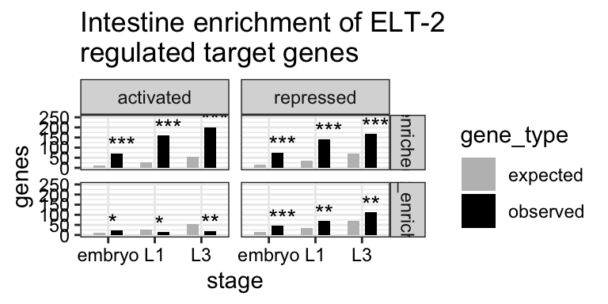

```r
bound_intestine_regulated_genes_plot <- bound_intestine_regulated_genes %>%
  ggplot(aes(x = stage, y = genes, fill = gene_type, label = star)) +
  geom_bar(position = position_dodge(width=0.75), stat = "identity", width = 0.5) +
  geom_text(vjust = 0, hjust = 0) +
  scale_fill_manual(values = c("grey", "black")) +
  theme_bw() +
  ylim(c(0,max(bound_intestine_regulated_genes$genes)+50)) +
  facet_grid(intestine_expression~elt2_ko) +
  theme(axis.text.x=element_text(colour="black"),
        axis.text.y=element_text(colour="black")) +
  ggtitle("Intestine enrichment of ELT-2\nregulated target genes")

bound_intestine_regulated_genes_plot
```

```r
ggsave(bound_intestine_regulated_genes_plot, file = "../03_output/Gene_Set_Overlaps/bound_intestine_regulated_gene_counts_plot.pdf", width = 4, height = 3.25)
```

Interpretation: Repressed target genes are representative of both intestine enriched and not intestine enriched genes. Activated target genes are primarily intestine enriched. Targets independent of ELT-2 regulation are primarily not intestine enriched.

# Question: what tissues are ELT-2 regulated genes expressed in?

```r
tissue_specific_genes <- read_csv(file = "../../01_tissue_specific_genes/03_output/tissue_specific_genes_220202.csv")
```

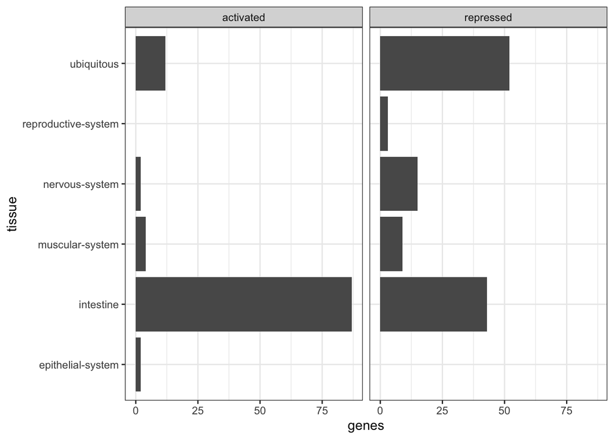

```r
all_stages_chip %>% filter(promoter_status == "bound", elt2_ko != "independent") %>% inner_join(tissue_specific_genes, by = "WBGeneID") %>%
  group_by(tissue, elt2_ko) %>% summarise(genes = n()) %>%
  ggplot(aes(x = tissue, y = genes)) +
  geom_bar(stat = "identity") +
  coord_flip() +
  theme_bw() +
  facet_grid(.~elt2_ko)
```

Interpretation: ELT-2 repressed targets are expressed in both intestine and reproductive, nervous, and muscular systems. ELT-2 activated targets are primarily intestine genes with some muscle and epithelial genes.

# Calculate hypergeometric statistc

```r
# all_stages_chip %>% filter(promoter_status == "bound") %>% right_join(tissue_specific_genes, by = "WBGeneID") %>%
#   group_by(stage, tissue, elt2_ko) %>% summarise(observed = n()) %>%
#   ungroup() %>%
#   left_join(tissue_specific_genes %>% group_by(tissue) %>% summarise(genes_per_tissue = n()), by = "tissue") %>%
#   rowwise()
#   mutate(pop_bound_success, pop_bound_fail)
#
# group_by(stage, elt2_ko) %>%
#   mutate(elt2_ko_totals = sum(observed)) %>%
#   ungroup() %>%
#   group_by(stage, tissue) %>%
#   mutate(tissue_totals = sum(observed)) %>%
#   mutate(pop_bound_success = 541, pop_bound_fail = 1698) %>%
#   ungroup() %>%
#   rowwise() %>%
#   mutate(dhyper = dhyper(x = observed, k = elt2_ko_totals , m = pop_bound_success, n = pop_bound_fail),
#          expected = elt2_ko_totals*pop_bound_success/(pop_bound_success+pop_bound_fail)) %>%
#   pivot_longer(cols = c(observed, expected), names_to = "gene_type", values_to = "genes")%>%
#   ungroup() %>%
#   mutate(padj = p.adjust(dhyper, method = "BH")) %>%
#   mutate(star = case_when(
#     gene_type == "observed" & padj > 0.01 ~ "~",
#     gene_type == "observed" & padj < 1*10^-10 ~ "***",
#     gene_type == "observed" & padj < 1*10^-5 ~ "**",
#     gene_type == "observed" & padj < 0.01 ~ "*"
#                           ))

# the urn is full of balls that are associated with a given tissue term for one developmental stage
# population success is all bound regulated genes with given tissue ID regardless of stage
# fail is all bound genes without that tissue ID

# tissue_specific_genes %>% group_by(tissue) %>% summarise(genes_per_tissue = n())
#
# all_stages_chip %>%
#   filter(promoter_status == "bound", elt2_ko == "activated", stage == "L1") %>%
#   left_join(tissue_specific_genes, by = "WBGeneID") %>%
#   group_by(tissue, stage) %>%
#   summarise(tissue_stage_observed = n()) %>%
#   ungroup() %>%
#   left_join(all_stages_chip %>%
#     filter(promoter_status == "bound") %>%
#     group_by(stage, elt2_ko) %>%
#     summarise(stage_gene_total = n()), by = "stage"
#     ) %>%
#   left_join(
#     all_stages_chip %>%
#     filter(stage == "L1") %>%
#     left_join(tissue_specific_genes, by = "WBGeneID") %>%
#     group_by(tissue) %>%
#     summarise(stage_tissue_total = n()),
#     by = "tissue"
#   ) %>%
#   rowwise() %>%
#   mutate(pop_bound_tissue_fail = stage_gene_total-pop_tissue_success) %>%
#   mutate(dhyper = dhyper(x = tissue_stage_observed, k = stage_gene_total , m = pop_tissue_success, n = pop_bound_tissue_fail),
#          expected = stage_gene_total*pop_tissue_success/(pop_tissue_success+pop_bound_tissue_fail)) %>%
#   mutate(padj = p.adjust(dhyper, method = "BH"))
```

```r
# # K: Number of balls drawn from the urn
# k <- all_stages_chip %>% filter(stage == "L1", promoter_status == "bound", elt2_ko == "repressed") %>% summarise(n()) %>% pull()
# k
# # X: number of white balls drawn when "intestine" is success
#
# x <- all_stages_chip %>% left_join(tissue_specific_genes, by = "WBGeneID")%>% filter(stage == "L1", promoter_status == "bound", elt2_ko == "repressed", tissue == "intestine") %>% summarise(n()) %>% pull()
# x
# # M: number of white balls in the urn
#
# m <- all_stages_chip %>% left_join(tissue_specific_genes, by = "WBGeneID")%>% filter(stage == "L1", promoter_status == "bound", tissue == "intestine") %>% summarise(n()) %>% pull()
# m
# # N: number of black balls in the urn
# n <- all_stages_chip %>% left_join(tissue_specific_genes, by = "WBGeneID")%>% filter(stage == "L1", promoter_status == "bound") %>% summarise(bound_stage_total =n()) %>% pull()-m
# n
# dhyper(x = x, m = m, n = n, k =k)
```

```r
# K: number of balls drawn, number of genes that are bound and regulated
# X: number of bound and regulated genes that are associated with a given tissue term
# M: total number of genes associated with a given tissue term
# N: total number of genes associated with any tissue term minus M
bound_regulated_tissue_hyper <- all_stages_chip %>% left_join(tissue_specific_genes, by = "WBGeneID") %>%
  filter(elt2_ko != "independent", promoter_status == "bound") %>%
  group_by(promoter_status, elt2_ko, tissue) %>%
  summarise(bound_tissue_regulated_total = n()) %>%
  ungroup() %>%
  bind_rows(tribble(~promoter_status, ~elt2_ko, ~tissue, ~bound_tissue_regulated_total,
                   "bound", "activated", "reproductive-system", 0,
                   "bound", "repressed", "epithelial-system", 0)) %>%
  left_join(all_stages_chip %>%
              filter(elt2_ko != "independent", promoter_status == "bound") %>%
              group_by(elt2_ko) %>%
              summarise(bound_reg_total = n()),
            by = c("elt2_ko")) %>%
  left_join(tissue_specific_genes %>%
              group_by(tissue) %>%
              summarise(tissue_success = n()) %>%
              rowwise() %>%
              mutate(tissue_total = nrow(tissue_specific_genes), tissue_fail = tissue_total - tissue_success),
            by = "tissue") %>%
  drop_na(tissue) %>%
  mutate(dhyper = dhyper(x = bound_tissue_regulated_total, k = bound_reg_total , m = tissue_success, n = tissue_fail),
         expected = bound_reg_total*tissue_success/(tissue_success+tissue_fail)) %>%
  mutate(padj = p.adjust(dhyper, method = "BH"))
bound_regulated_tissue_hyper <- bound_regulated_tissue_hyper %>%
  rename(observed = bound_tissue_regulated_total) %>%
  pivot_longer(cols = c(observed, expected), names_to = "gene_type", values_to = "genes") %>%
  mutate(star = case_when(
    gene_type == "observed" & padj > 0.01 ~ "~",
    gene_type == "observed" & padj < 1*10^-10 ~ "***",
    gene_type == "observed" & padj < 1*10^-5 ~ "**",
    gene_type == "observed" & padj < 0.01 ~ "*"
                          ))
```

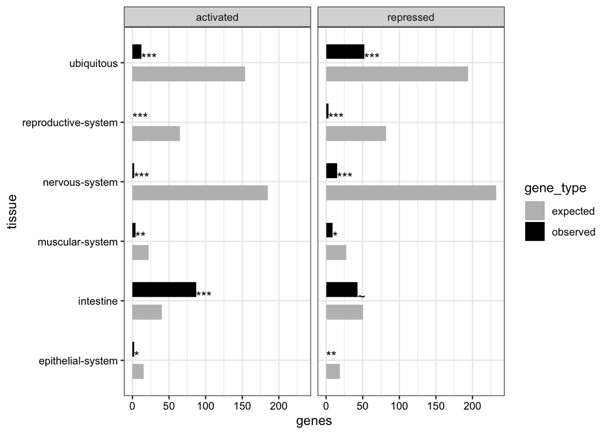

```r
bound_regulated_tissue_hyper_plot <- bound_regulated_tissue_hyper %>%
ggplot(aes(x = tissue, y = genes, fill = gene_type, label = star)) +
  geom_bar(position = position_dodge(width=0.75), stat = "identity", width = 0.5) +
  scale_fill_manual(values = c("grey", "black")) +
  geom_text(hjust = 0, vjust = 0)+
  facet_grid(~elt2_ko) +
  theme_bw() +
  theme(axis.text.x=element_text(colour="black"),
        axis.text.y=element_text(colour="black")) +
  coord_flip()
bound_regulated_tissue_hyper_plot
```

```r
ggsave(bound_regulated_tissue_hyper_plot, file = "../03_output/Gene_Set_Overlaps/bound_regulated_tissue_hyper_plot.pdf", width = 5, height = 2.5)
```

Remove developmental stages?

```r
# bound_regulated_tissue_hyper %>% rename(observed = stage_bound_tissue_regulated_total) %>% pivot_longer(cols = c(observed, expected), names_to = "gene_type", values_to = "genes")%>%
#   ungroup() %>%
#   mutate(padj = p.adjust(dhyper, method = "BH")) %>%
#   mutate(star = case_when(
#     gene_type == "observed" & padj > 0.01 ~ "~",
#     gene_type == "observed" & padj < 1*10^-10 ~ "***",
#     gene_type == "observed" & padj < 1*10^-5 ~ "**",
#     gene_type == "observed" & padj < 0.01 ~ "*"
#                           )) %>%
#   ggplot(aes(x = tissue, y = genes, fill = gene_type, label = star)) +
#   geom_bar(stat = "identity", position = "dodge") +
#   scale_fill_manual(values = c("grey", "black")) +
#   geom_text() +
#   facet_grid(stage~elt2_ko) +
#   coord_flip() +
#   theme_bw()
```

# Stacked bar plots

## Question: What is the fraction of ELT-2 bound enriched genes?

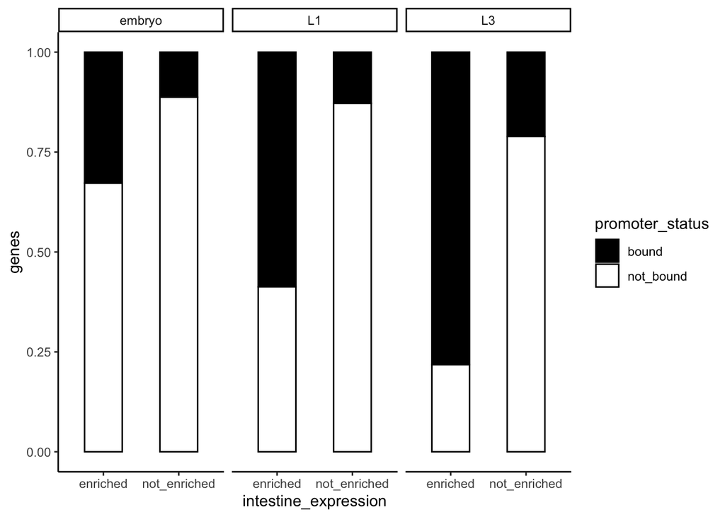

```r
all_stages_chip %>% group_by(stage, intestine_expression, promoter_status) %>% summarise(genes = n()) %>%
  ggplot(aes(x = intestine_expression, y = genes, fill = promoter_status)) +
  geom_bar(stat = "identity", position = "fill", color = "black", width = 0.5) +
  scale_fill_manual(values = c("black", "white")) +
  facet_wrap(~stage) +
  theme_classic()
```

```r
q1_contingency_df <-
  all_stages_chip %>% group_by(stage, intestine_expression, promoter_status) %>% summarise(genes = n()) %>%
  ungroup()  %>%
  pivot_wider(values_from = genes, names_from = promoter_status)
for(i in unique(q1_contingency_df$stage)){
  # print(i)
  pval <- fisher.test(q1_contingency_df %>% filter(stage == i) %>% select(-stage, -intestine_expression))$p.value
  print(c(i, pval))
}
```

```
## [1] "embryo"                "3.16035202206925e-111"
## [1] "L1" "0"
## [1] "L3" "0"
```

## Question: What is the fraction of transcriptionally dependent ELT-2 targets?

```
## 'promoter_status'. You can override using the `.groups` argument.
```

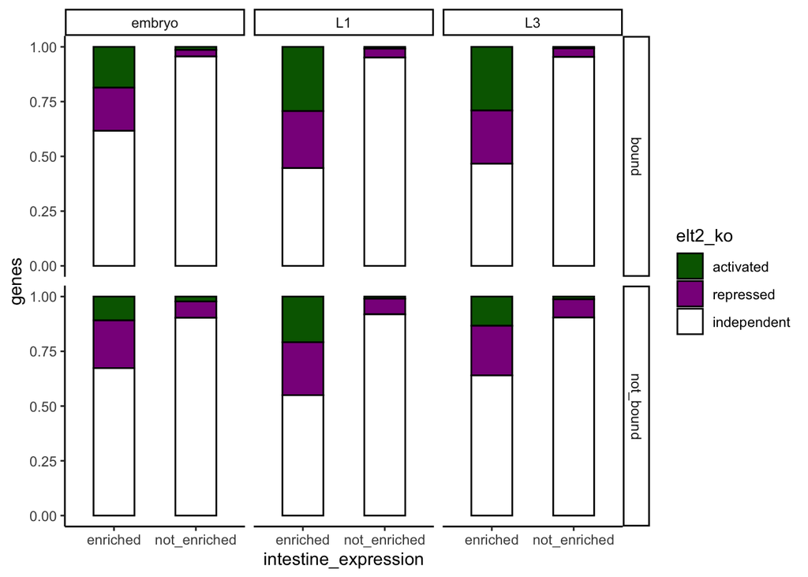

```r
all_stages_chip %>% group_by(stage, intestine_expression, promoter_status, elt2_ko) %>% summarise(genes = n()) %>% drop_na(elt2_ko) %>%
  ggplot(aes(x = intestine_expression, y = genes, fill = elt2_ko, width = 0.5)) +
  geom_bar(stat = "identity", position = "fill", color = "black") +
  scale_fill_manual(values = c("darkgreen", "darkmagenta", "white")) +
  facet_grid(promoter_status~stage) +
  theme_classic()
```

```r
q2_contingency_df <-
  all_stages_chip %>% group_by(stage, intestine_expression, promoter_status, elt2_ko) %>% summarise(genes = n()) %>% drop_na(elt2_ko) %>%
  ungroup()  %>%
  pivot_wider(values_from = genes, names_from = elt2_ko)
```

```
## 'promoter_status'. You can override using the `.groups` argument.
```

```r
for(i in unique(q2_contingency_df$stage)){
  # print(i)
  for(j in c("bound", "not_bound")){
    pval <- fisher.test(q2_contingency_df %>% filter(stage == i, promoter_status == j) %>% select(-(stage:promoter_status)))$p.value
    print(c(i, j,pval))
  }
}
```

```
## [1] "embryo"              "bound"               "1.4217588481993e-62"
## [1] "embryo"               "not_bound"            "1.40642822462643e-54"
## [1] "L1"                    "bound"                 "1.50809221030566e-148"
## [1] "L1"                   "not_bound"            "3.32973488887906e-81"
## [1] "L3"                    "bound"                 "1.86376847771144e-202"
## [1] "L3"                   "not_bound"            "5.75981824623414e-21"
```

```r
fisher.test(q2_contingency_df %>% filter(stage == "embryo", promoter_status == "bound") %>% select(-(stage:promoter_status)))$p.value
```

```
## [1] 1.421759e-62
```

```
## 'promoter_status'. You can override using the `.groups` argument.
```

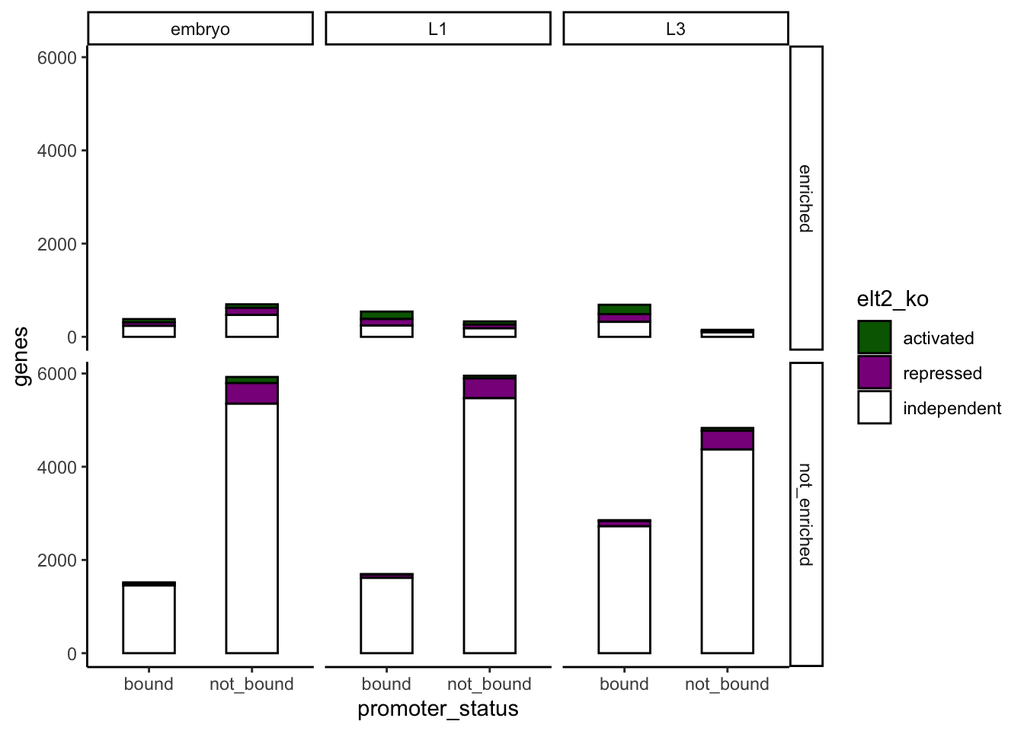

```r
all_stages_chip %>% group_by(stage, intestine_expression, promoter_status, elt2_ko) %>% summarise(genes = n()) %>% drop_na(elt2_ko) %>%
  ggplot(aes(x = promoter_status, y = genes, fill = elt2_ko, width = 0.5)) +
  geom_bar(stat = "identity", position = "stack", color = "black") +
  scale_fill_manual(values = c("darkgreen", "darkmagenta", "white")) +
  facet_grid(intestine_expression~stage) +
  theme_classic()
```

```r
# +
 # scale_y_log10()
```

```
## 'promoter_status'. You can override using the `.groups` argument.
```

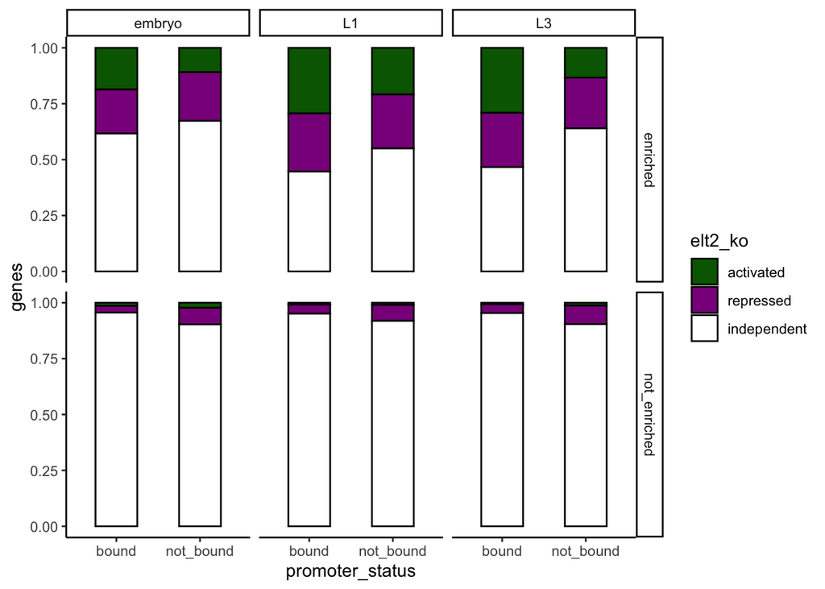

```r
all_stages_chip %>% group_by(stage, intestine_expression, promoter_status, elt2_ko) %>% summarise(genes = n()) %>% drop_na(elt2_ko) %>%
  ggplot(aes(x = promoter_status, y = genes, fill = elt2_ko, width = 0.5)) +
  geom_bar(stat = "identity", position = "fill", color = "black") +
  scale_fill_manual(values = c("darkgreen", "darkmagenta", "white")) +
  facet_grid(intestine_expression~stage) +
  theme_classic()
```

```r
for(i in unique(q2_contingency_df$stage)){
  # print(i)
  for(j in c("enriched", "not_enriched")){
    pval <- fisher.test(q2_contingency_df %>% filter(stage == i, intestine_expression == j) %>% select(-(stage:promoter_status)))$p.value
    print(c(i, j,pval))
  }
}
```

```
## [1] "embryo"              "enriched"            "0.00227850105422124"
## [1] "embryo"              "not_enriched"        "9.8118677736796e-12"
## [1] "L1"                  "enriched"            "0.00524900058177075"
## [1] "L1"                   "not_enriched"         "9.56089308080801e-06"
## [1] "L3"                   "enriched"             "3.55143101681759e-05"
## [1] "L3"                   "not_enriched"         "4.71006642579496e-15"
```

# Transcription factor ELT-2 targets

Load data

```r
# TF list
wtf3 <- read_csv("../../03_emb_L1_L3_intestine_RNAseq/01_input/TF3-0_namesonly.csv") %>% filter(!grepl("mex", Public_name))
GO_TFs <- read_delim("../01_input/elegans_genes_direct_and_inferred_for_GO_0001067_transcription_region_binding.txt", col_names = c("WBGeneID", "gene_name", "species")) %>% bind_rows(read_delim("../01_input/elegans_genes_direct_and_inferred_for_GO_0003700_transcription_factors.txt", col_names = c("WBGeneID", "gene_name", "species"))) %>% distinct(WBGeneID, .keep_all = TRUE)
# embryo
res_embryoGFPplus_vs_embryoGFPminus_ashr_shrunk <- read_csv(file = "../../03_emb_L1_L3_intestine_RNAseq/03_output/pairwise_shrunk_DE_results/res_embryoGFPplus_vs_embryoGFPminus_ashr_shrunk.csv")
res_elt2D_v_wt_ashr_shrunk <- read_csv("../../05_elt2_RNAseq/03_output/res_elt2D_v_wt_ashr_shrunk.csv")
embryo_intestine_gene_categories<- read_csv("../../03_emb_L1_L3_intestine_RNAseq/03_output/intestine_gene_categories/embryo_intestine_gene_categories.csv")
embryo_rna_chip_FC <- embryo_rna_chip %>%
  select(-intestine_expression) %>%
  left_join(embryo_intestine_gene_categories, by = "WBGeneID") %>%
  left_join(res_embryoGFPplus_vs_embryoGFPminus_ashr_shrunk %>% select(gutFC = log2FoldChange, WBGeneID), by = "WBGeneID") %>%
  left_join(res_elt2D_v_wt_ashr_shrunk %>% dplyr::select(elt2FC = log2FoldChange, WBGeneID), by = "WBGeneID") %>%
  replace_na(list(gutFC = 0, elt2FC = 0))
# L1
res_L1GFPplus_vs_L1GFPminus_ashr_shrunk <- read_csv(file = "../../03_emb_L1_L3_intestine_RNAseq/03_output/pairwise_shrunk_DE_results/res_L1GFPplus_vs_L1GFPminus_ashr_shrunk.csv")
res_elt2D_v_wt_ashr_shrunk <- read_csv("../../05_elt2_RNAseq/03_output/res_elt2D_v_wt_ashr_shrunk.csv")
L1_intestine_gene_categories<- read_csv("../../03_emb_L1_L3_intestine_RNAseq/03_output/intestine_gene_categories/L1_intestine_gene_categories.csv")
L1_rna_chip_FC <- L1_rna_chip %>%
  select(-intestine_expression) %>%
  left_join(L1_intestine_gene_categories, by = "WBGeneID") %>%
  left_join(res_L1GFPplus_vs_L1GFPminus_ashr_shrunk %>% select(gutFC = log2FoldChange, WBGeneID), by = "WBGeneID") %>%
  left_join(res_elt2D_v_wt_ashr_shrunk %>% select(elt2FC = log2FoldChange, WBGeneID), by = "WBGeneID") %>%
  replace_na(list(gutFC = 0, elt2FC = 0))
# L3
res_L3GFPplus_vs_L3GFPminus_ashr_shrunk <- read_csv(file = "../../03_emb_L1_L3_intestine_RNAseq/03_output/pairwise_shrunk_DE_results/res_L3GFPplus_vs_L3GFPminus_ashr_shrunk.csv")
res_elt2D_v_wt_ashr_shrunk <- read_csv("../../05_elt2_RNAseq/03_output/res_elt2D_v_wt_ashr_shrunk.csv")
L3_intestine_gene_categories<- read_csv("../../03_emb_L1_L3_intestine_RNAseq/03_output/intestine_gene_categories/L3_intestine_gene_categories.csv")
L3_rna_chip_FC <- L3_rna_chip %>%
  select(-intestine_expression) %>%
  left_join(L3_intestine_gene_categories, by = "WBGeneID") %>%
  left_join(res_L3GFPplus_vs_L3GFPminus_ashr_shrunk %>% select(gutFC = log2FoldChange, WBGeneID), by = "WBGeneID") %>%
  left_join(res_elt2D_v_wt_ashr_shrunk %>% select(elt2FC = log2FoldChange, WBGeneID), by = "WBGeneID") %>%
  replace_na(list(gutFC = 0, elt2FC = 0))
```

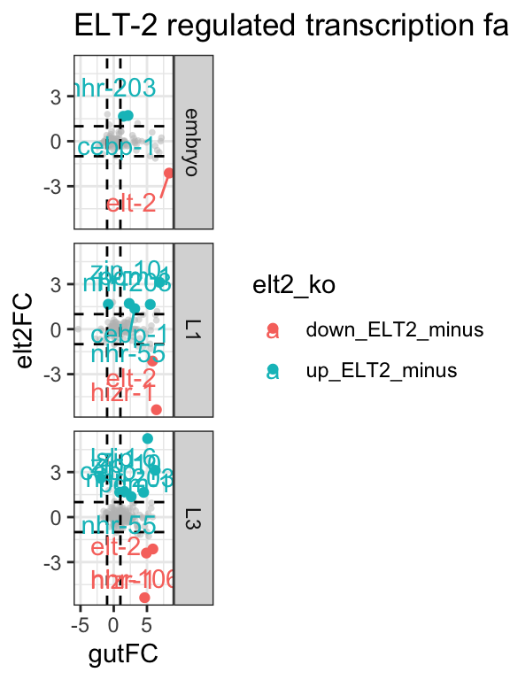

```r
all_stage_rna_chip_FC <- embryo_rna_chip_FC %>% mutate(stage = "embryo") %>%
  bind_rows(L1_rna_chip_FC %>% mutate(stage = "L1")) %>%
  bind_rows(L3_rna_chip_FC %>% mutate(stage = "L3")) %>%
  filter(gutFC > -20)

all_stage_rna_chip_FC %>%
  filter(promoter_status == "bound", elt2_ko %in% c("up_ELT2_minus", "down_ELT2_minus")) %>%
  inner_join(GO_TFs, by = "WBGeneID") %>%
  ggplot(aes(x = gutFC, y = elt2FC, label = gene_name, color = elt2_ko)) +
  geom_point(data = all_stage_rna_chip_FC %>%
               filter(WBGeneID %in% GO_TFs$WBGeneID,
                      promoter_status == "bound") %>%
               select(gutFC, elt2FC, stage), color = "grey", size = 1, alpha = 0.5, shape = 16, aes(label = NULL)) +
  geom_point() +
  geom_hline(yintercept = c(-1,1), linetype = 2) +
  geom_vline(xintercept = c(-1,1), linetype = 2) +
  ggrepel::geom_text_repel(box.padding = 0.5, max.overlaps = 100, force = 5) +
  facet_grid(stage~.) +
  ggtitle("ELT-2 regulated transcription factors") +
  theme_bw()
```

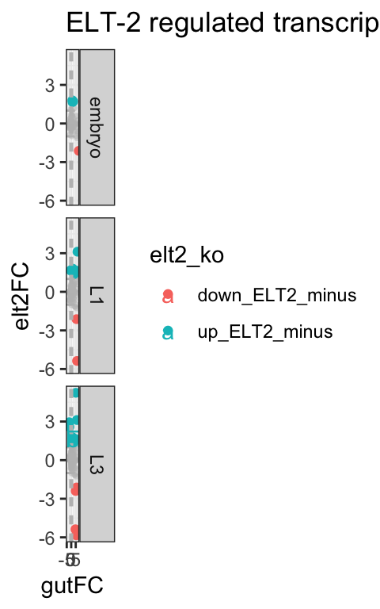

```r
elt2_target_TFs_plot <- all_stage_rna_chip_FC %>%
  filter(promoter_status == "bound", elt2_ko %in% c("up_ELT2_minus", "down_ELT2_minus")) %>%
  inner_join(wtf3, by = "WBGeneID") %>%
  ggplot(aes(x = gutFC, y = elt2FC, label = Public_name, color = elt2_ko)) +
  geom_point(data = all_stage_rna_chip_FC %>%
               filter(WBGeneID %in% GO_TFs$WBGeneID,
                      promoter_status == "bound") %>%
               select(gutFC, elt2FC, stage), color = "grey", size = 1, alpha = 0.5, shape = 16, aes(label = NULL)) +
  geom_point() +
  geom_hline(yintercept = c(-1,1), linetype = 2, color = "grey") +
  geom_vline(xintercept = c(-1,1), linetype = 2,color = "grey") +
  ggrepel::geom_text_repel(box.padding = 0.5, max.overlaps = 100, force = 5) +
  facet_grid(stage~.) +
  ggtitle("ELT-2 regulated transcription factors") +
  theme_bw()

elt2_target_TFs_plot
```

```r
ggsave(filename = "../03_output/elt2_target_TFs_plot.pdf", width = 4.5, height = 5.5)
```

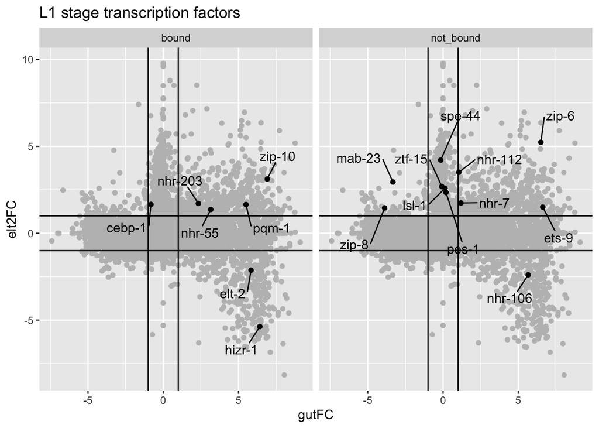

```r
L1_rna_chip_FC %>%
  filter(elt2_ko %in% c("up_ELT2_minus", "down_ELT2_minus")) %>%
  inner_join(GO_TFs, by = "WBGeneID") %>%
  ggplot(aes(x = gutFC, y = elt2FC, label = gene_name)) +
  # ggplot(aes(x = gutFC, y = elt2FC)) +
  geom_point(data = L1_rna_chip_FC %>% select(gutFC, elt2FC) %>% filter(gutFC > -20), color = "grey", aes(label = NULL)) +
  geom_point() +
  geom_hline(yintercept = c(-1,1)) +
  geom_vline(xintercept = c(-1,1)) +
  ggrepel::geom_text_repel(box.padding = 1, max.overlaps = 100) +
  facet_grid(~promoter_status) +
  ggtitle("L1 stage transcription factors")
```

```r
# L1_rna_chip_FC %>% group_by(elt2_ko, intestine_expression, promoter_status) %>% summarise(n())
```

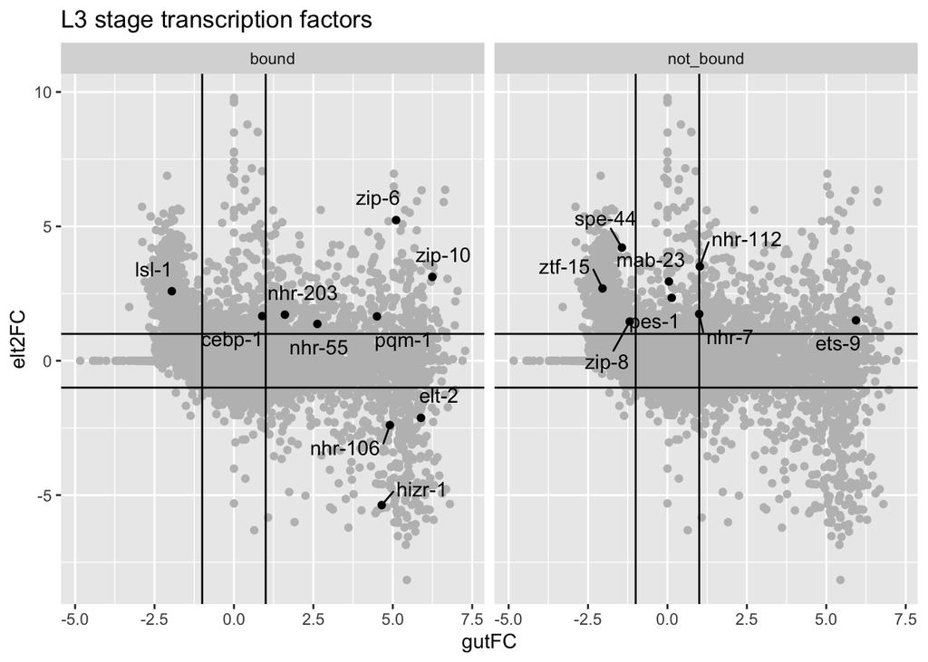

```r
L3_rna_chip_FC %>%
  filter(elt2_ko %in% c("up_ELT2_minus", "down_ELT2_minus")) %>%
  inner_join(GO_TFs, by = "WBGeneID") %>%
  ggplot(aes(x = gutFC, y = elt2FC, label = gene_name)) +
  # ggplot(aes(x = gutFC, y = elt2FC)) +
  geom_point(data = L3_rna_chip_FC %>% select(gutFC, elt2FC) %>% filter(gutFC > -20), color = "grey", aes(label = NULL)) +
  geom_point() +
  geom_hline(yintercept = c(-1,1)) +
  geom_vline(xintercept = c(-1,1)) +
  ggrepel::geom_text_repel(box.padding = 0.5, max.overlaps = 100) +
  facet_grid(~promoter_status) +
  ggtitle("L3 stage transcription factors")
```

```r
# L3_rna_chip_FC %>% group_by(elt2_ko, intestine_expression, promoter_status) %>% summarise(n())
```